# Stationary Profiles Unsaturated Zone

# Background

The Richards equation

The Retention curves

Loading the soil data

| x |
| --- |
| Soil type: B1 Non-loamy sand |
| Soil type: B2 Loamy sand |
| Soil type: B3 Very loamy sand |
| Soil type: B4 Extremely loamy sand |
| Soil type: B5 Coarse sand |
| Soil type: B6 Boulder clay |
| Soil type: B7 Sandy loam |
| Soil type: B8 Silt loam |
| Soil type: B9 Clayey loam |
| Soil type: B10 Light clay |
| Soil type: B11 Heavy clay |
| Soil type: B12 Very heavy clay |
| Soil type: B13 Loam |
| Soil type: B14 Heavy loam |
| Soil type: B15 Peaty sand |
| Soil type: B16 Sandy peat |
| Soil type: B17 Peaty clay |
| Soil type: B18 Clayey peat |
| Soil type: O1 Non-loamy sand |
| Soil type: O2 Loamy sand |
| Soil type: O3 Very loamy sand |
| Soil type: O4 Extremely loamy sand |
| Soil type: O5 Coarse sand |
| Soil type: O6 Boulder clay |
| Soil type: O7 River loam |
| Soil type: O8 Sandy loam |
| Soil type: O9 Silt loam |
| Soil type: O10 Clayey loam |
| Soil type: O11 Light clay |
| Soil type: O12 Heavy clay |
| Soil type: O13 Very heavy clay |
| Soil type: O14 Loam |
| Soil type: O15 Heavy loam |
| Soil type: O16 Oligotrophic peat |
| Soil type: O17 Eutrophic peat |
| Soil type: O18 Peaty layer |

Plotting the retention curves for specific soil types

```
#number of data points in pF range:
pF = seq(0.01,4.2,by=0.05)
psi = -10^(pF)
soil = soil.set$B13
plot(soil$k.fun(psi),psi,type="l",col="red",ylab="Pressure head",xlab="Hydraulic conductivity")
```

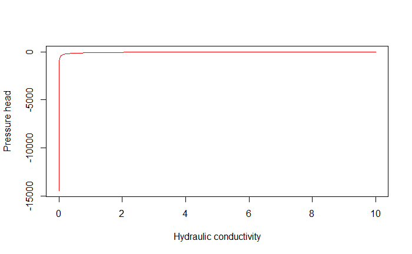

```
plot(soil$k.fun(psi),log10(-psi),log = "y", type="l",col="red",ylab="Pressure head in pF",xlab="Hydraulic conductivity")
```

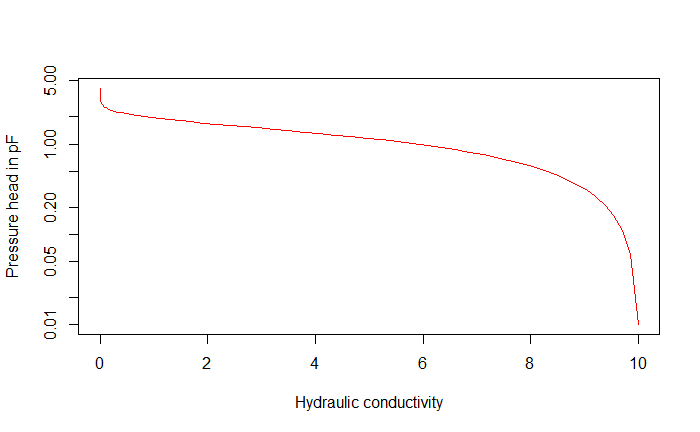

```
plot(soil$theta.fun(psi),psi,type="l",col="red",ylab="Pressure head",xlab="Water content")
```

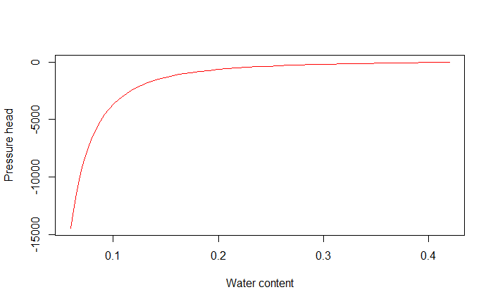

```
plot(soil$theta.fun(psi),log10(-psi),log = "y", type="l",col="red",ylab="Pressure head in pF",xlab="Water content")
```

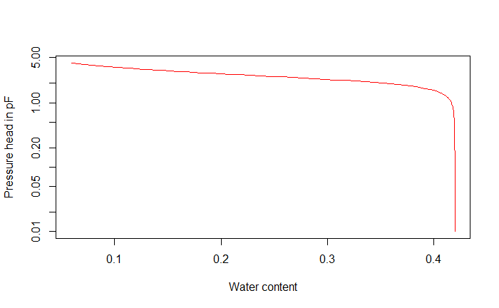

```
#plotting the retention curves
plot(soil.set$Clay$ThetaS,soil.set$Clay$ThetaR,type="l",col="red",ylim=c(0,1),xlim=c(0,1),xlab="Water content",ylab="Pressure head")
```

[figure not shown]

```
# library(plotly)
# p <- plot_ly(x = ~soil$k.fun(psi), y = ~log10(-psi), type = 'scatter', mode = 'lines',
#              line = list(color = 'red')) %>%
#   layout(title = 'Hydraulic Conductivity vs Pressure Head',
#          xaxis = list(title = 'Hydraulic conductivity'),
#          yaxis = list(title = 'Pressure head'))
#
# # Toon de plot
# p
```

# Stationary profiles

The Richards equation is a partial differential equation that describes the flow of water in unsaturated soils. The equation is given by the following equation. Flow in the unsaturated zone is predominantly vertical so here we only consider flow in the $z$ direction equation.

$$\frac{\partial \theta}{\partial t} = \frac{\partial q}{\partial z}\\
\frac{\partial \theta}{\partial t} = \frac{\partial}{\partial z} \left\{
K(\psi) \left ( \frac{\partial psi}{\partial z} +1 \right) \right\}$$

Here we will focus on the general behaviour of flow in the unsaturated zone under stationary conditions for situations with deep and shallow groundwater tables and with different flux rates.

Since we only consider stationary flow, the time derivative is zero. The equation simplifies to:

$$\text{Constant} = \frac{\partial}{\partial z} \left\{ K(\psi) \left (
\frac{\partial \psi}{\partial z} +1 \right) \right\}$$
And since this derivative $\frac{\partial}{\partial z}$ is zero for now but is actually the flux rate. The equation simplifies to:

1. Define the soil type
2. Define the domain of the model
3. Define the boundary conditions
4. Solve the equation

## Soil type

Choose one of the soil types given in the `soil.set` object.

## Domain

Since we are interested in the effect of large and small unsaturated zones the domains could be defined as one being 15 meters and the other 1 meter.

## Boundary conditions

On top of the domain, i.e. at the surface the flux rate will be given. A positive value indicates an influx, coming from precipitation for example. A negative value indicates an outflux, for example evaporation (bij soil and roots). At the bottom of the domain the pressure head is given. This is the pressure head of the groundwater table.

## Solve the equation

Here we are going to apply an explicit scheme to calculate the pressure head (i.e. $\psi$) in the unsaturated zone. The differential in the (Darcy like) equation is now approximated by a finite differences:

$$\frac{\partial \psi}{\partial z} \approx \frac{\psi_{z}-\psi_{z-\Delta
z}}{\Delta z}$$

Rewrite the Darcy alike question into a finite difference equation that calculates the pressure head at depth $z$, based on all the other terms.

$$\psi_{z} = \psi_{z-\Delta z} + \left( \frac{q_{z}}{K(\psi_{z-\Delta
z})} - 1 \right)\Delta z$$

## Implementation

It is custom in the vadoze zone hydrology to use centimeters for the spatial scale. So the flux rate is given in cm/day. The hydraulic conductivity is given in cm/day. The pressure head is given in cm.

```
#defining the soil type
#soil = soil.set$B13
soil = soil.set$O2
soil_name = soil$name

#defining the domain
dz = 1 #cm
psi = seq(-1500,0,by=dz) #cm
z = psi

#boundary conditions

#at the groundwater table the pressure head psi is 0.0
psi[1] = 0.0

#at the surface the flux rate is given
q = 0.01 #cm/day



for (i in 2:length(psi)){

    psi[i] = psi[i-1] + (q/soil$k.fun(psi[i-1]) - 1)*dz

}

oldpar = par(no.readonly = TRUE)

par(mfrow=c(1,2)) #this creates two plots next to each other

plot(z,rev(z),type= "l",lty= "dashed",col="blue",main = paste("Soil:",soil_name,"; q = ",q,"cm/day"),
     ylab="Depth (cm)",xlab="Pressure head (psi in cm)",xlim=range(psi))
lines(psi,z,type="l",col="red")
```

```
grid()

range_theta = c(soil$theta.res,soil$theta.sat)
plot(soil$theta.fun(psi),z,type="l",col="red",
     ylab="Depth (cm)",xlab="Water content",xlim=range_theta)
```

```
grid()

par(oldpar)
```

[figure not shown]

Checking the flux rate

```
#q = -k(psi)(dpsi/dz + 1))
q = soil$k.fun(psi)*(diff(psi)/dz + 1)
```